# Homework_9_Markdown

Samuel Guzman

11/29/2020

1. Comparing Means

To start with, let’s warm up with a simple one-way ANOVA model. This example, from Whitlock and Schluter chapter 15 question 22 looks at the mass of lodgepole pinecones from different habitats.

1.1. Load and plot the data. Choose a plot that not only shows the raw data, but also the means and SE or CI of those means. +1 EC if Michael thinks it’s fancy.

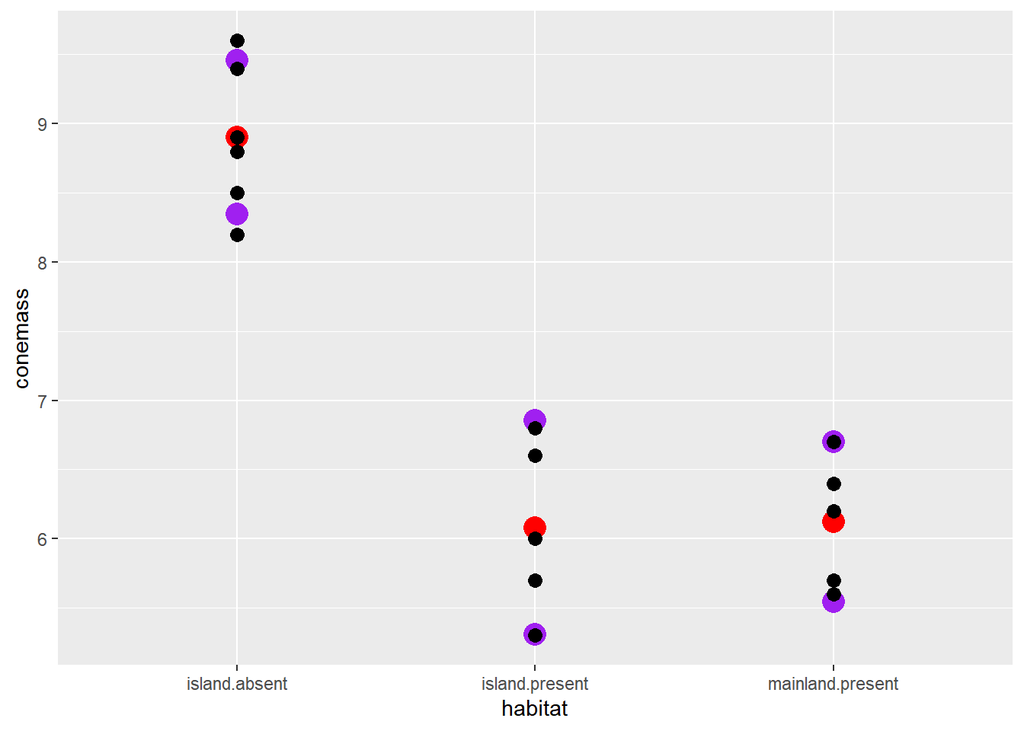

```r
# Load the data

pinecones <- read.csv("15q22LodgepolePineCones.csv")

# Because the question asks for means and "SE or CI", I decided not to use geom boxplot
# Calculate means and confidence intervals ####

# Filter to the habitats that I want

library(dplyr)
pinecones_island.absent <- pinecones %>%
filter(habitat == "island.absent")

pinecones_island.present <- pinecones %>%
filter(habitat == "island.present")

pinecones_mainland.present <- pinecones %>%
filter(habitat == "mainland.present")

# Begin calculating the mean and CI's and putting them in vector format

habitat_vec <- c("island.absent", "island.present", "mainland.present")
mean_vec <- c(mean(pinecones_island.absent$conemass),
              mean(pinecones_island.present$conemass),
              mean(pinecones_mainland.present$conemass))

# A function to get CI

get_CI <- function(data_for_CI){
  out <- t.test(data_for_CI)$conf.int
  return(out)
}

# Upper and lower values can be extracted with "[1]" and "[2]"

# Run the function for each habitat and create upper and lower CI vecs

pinecones_island.absent_CI <- get_CI(pinecones_island.absent$conemass)
pinecones_island.present_CI <- get_CI(pinecones_island.present$conemass)
pinecones_mainland.present_CI <- get_CI(pinecones_mainland.present$conemass)

CI_upper_vec <- c(pinecones_island.absent_CI[2],
                  pinecones_island.present_CI[2],
                  pinecones_mainland.present_CI[2])

CI_lower_vec <- c(pinecones_island.absent_CI[1],
                  pinecones_island.present_CI[1],
                  pinecones_mainland.present_CI[1])

# Compile everything together in a data frame

mean_and_CI_df <- data.frame(habitat = habitat_vec,
                             mean = mean_vec,
                             CI_upper = CI_upper_vec,
                             CI_lower = CI_lower_vec)

# Plot the data ####

library(ggplot2)
pen_plot_base_Q1 <- ggplot(data = pinecones,
                        mapping = aes(x = habitat,
                                      y = conemass))

pen_plot_base_Q1 +
  geom_point(data = mean_and_CI_df, aes(x = habitat, y = mean), size = 5, color = "red") + # Draw mean points
  geom_point(data = mean_and_CI_df, aes(x = habitat, y = CI_upper), size = 5, color = "purple") + # Draw CI_upper points
  geom_point(data = mean_and_CI_df, aes(x = habitat, y = CI_lower), size = 5, color = "purple") + # Draw CI_lower points
  geom_point(size = 3, color = "Black") # The original data
```

1.2 Fit a model using least squares and evaluate all relevant assumptions. List them out as you test them. Can we use this model? If not, fix it. But if we can, no fix is needed!

```r
# Libraries

library(car)
library(tidyverse)
```

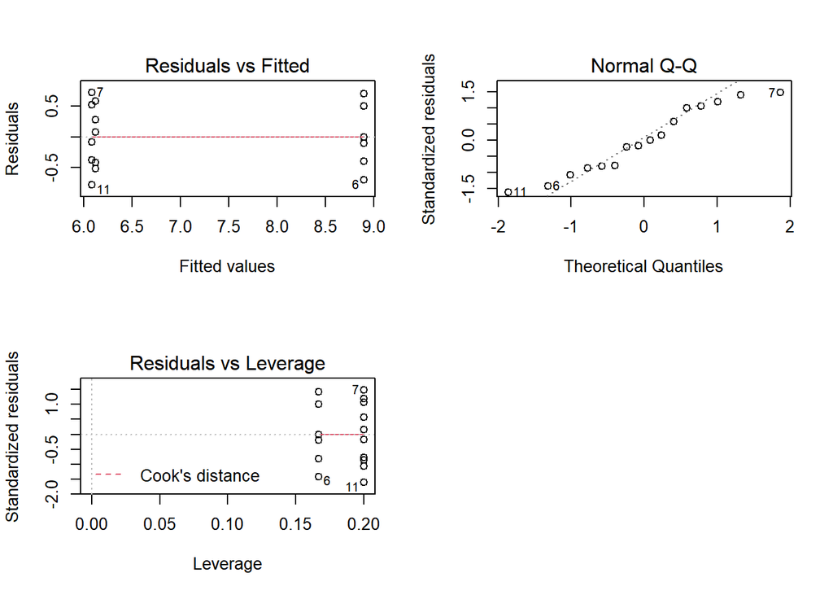

```r
library(ggplot2)
library(emmeans)

# The function lm() fits the relationship using least squares
pinecones_lm <- lm(data = pinecones, conemass~habitat)

# Similar code as in https://biol607.github.io/lab/10_anova.html

par(mfrow=c(2,2))
plot(pinecones_lm, which=c(1,2,5))
par(mfrow=c(1,1))
```